# CO2 Final Report

2023-05-05

## Global Warming Trends

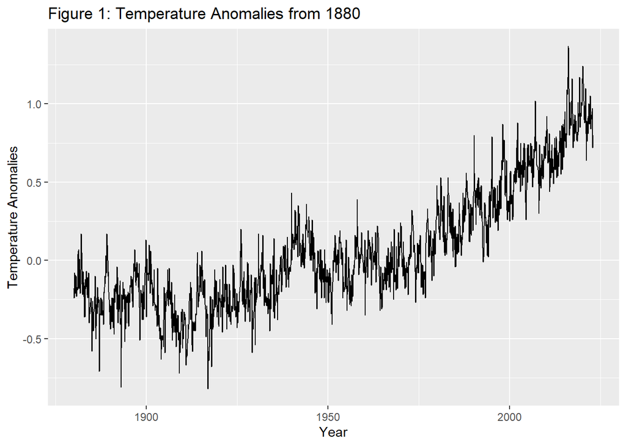

In this project, we aim to make predictions about the global temperature anomalies for the next 50 years based on ARIMA and Regression models. We will also try to say if the temperature increase trend is exponential.

## SARIMA Model Approach

The SARIMA Model is a time series model where we assume that the underlying process is an ARIMA process with seasonality. We try to find the best models with differencing set to 1. We try various models with various values for the seasonality, AR and MA parts of the model by looking at the ACF and PACF. We observed in the introduction that there is a change point in the 1950-60 decade. We try to fit a SARIMA model with a drift from a change point assumed to be in 1958 to the current date.

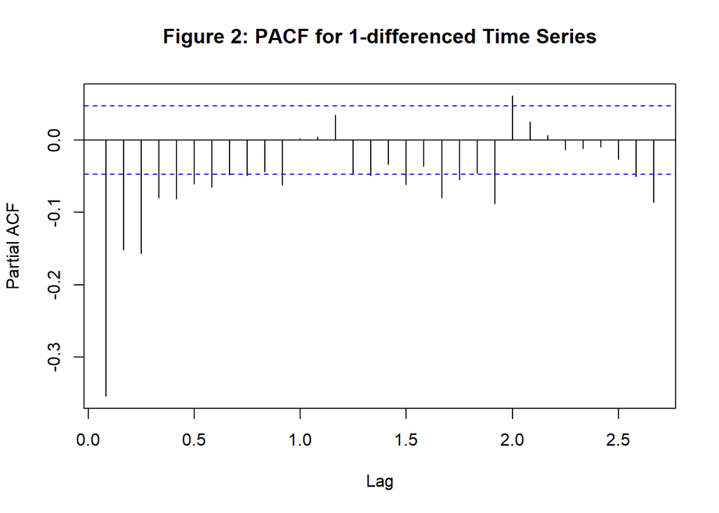

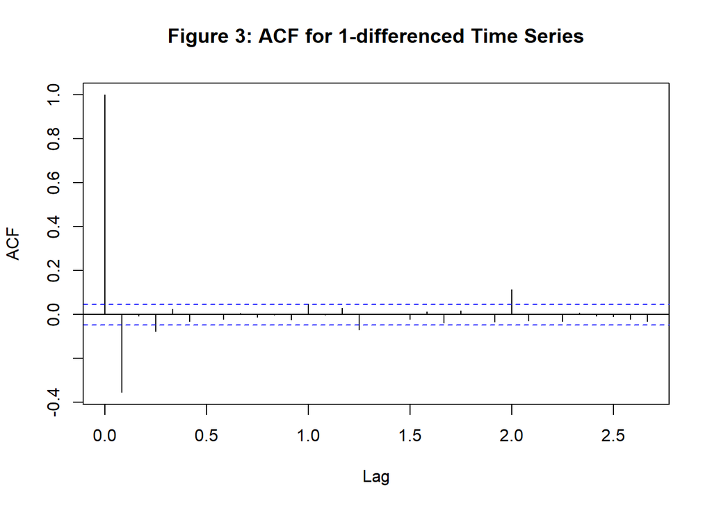

Thus, we have our candidate models for the ARIMA and try to find the best model using AIC and Residual error via Predictive Checking. We find that the Predictive error is minimised for the combination (1,1,1) with AR seasonality 1. But, the AIC is comparatively high for this combination compared to the other combinations, even when we consider the other models without seasonality. In the interest of having a simpler model, we decide to use the (2,1,1) model with AR seasonality 1 as the final model. Thus, the final model we have is a ARIMA model with differencing 1, and the AR component being 2 and the MA component being 1 and seasonality having one AR component. We remark that the prediction error is not very different across the models, even the ones without seasonality.

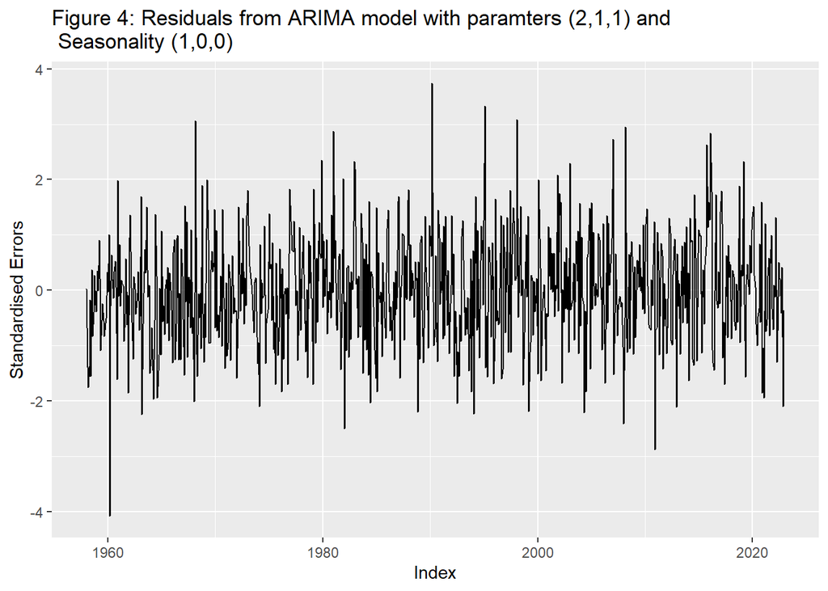

We look at the diagnostic plots for the final model in Figure 4 and observe that we do not observe any remaining dependence in the residuals. Thus, we believe that the model fits adequately to the data. We observe that 29 points are outside the $\pm2$ band and 5 points outside the $\pm3$ band. On testing against the NULL hypothesis that these residuals arise from a Standard Normal distribution, we see that the p value is close to 0.3, thus indicating that we do not have enough evidence to reject the Null hypothesis. But, we also observe quite a few residuals close to being 4 sd away from zero which suggests that the error distribution might not be normal.

## Predictions

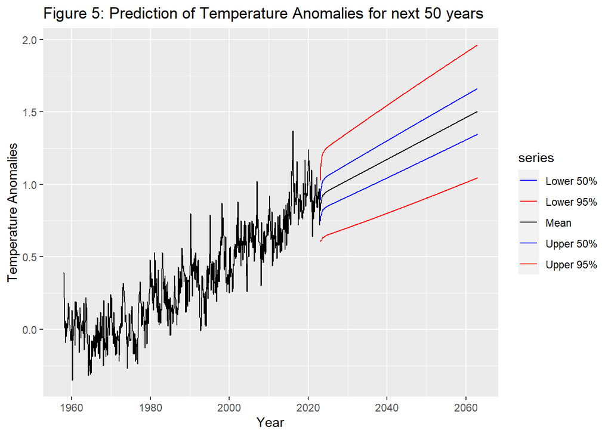

### Auto ARIMA Approach

We also supplied the data to the autoarima function of the Forecast library and found out that the best fit utilized a ARIMA(2,1,2) model without seasonality. Since the number of parameters is the same, it is not very obvious how the two models are different. But moving forward, we choose to utilize the (2,1,1) dependence structure without seasonality in the regression approach.

## Regression Approach

We observed in the previous section that differenced process after 1958 is appropriately modeled by the ARMA(2,1,1) model. In this section, we try to model the trend by regression instead of having a constant drift of the Arima function in the package forecast.

In this section, we model the drift using a linear, quadratic and an exponential term and select the appropriate trend. To incorporate the dependency structure due to the sequential nature of the data, we use the generalised least squares with the correlation structure corresponding to the ARMA(2,1) process.

Thus, the provisional model is as follows -

$$X_t = \beta_0 + \beta_1 \cdot t + \beta_2 \cdot t^2 + \beta_3 \cdot e
^{t/100} + C_{\text{Month}} \mathbf{1}_{\text{Month}} + \epsilon_t$$

We do a model-submodel test with and without the exponential term and find that the p-value is 0.27. This suggests that the exponential trend is not significant and the data is adequately modeled using a quadratic trend. We tried to change the coefficient to 500 in the Time scaling for the exponential term and still realised that it was still not significant. Thus, we can comfortably say that the there is not enough evidence in the data for an exponential trend. We also remark that we have to fit the models using the ML approach as using ReML would make us unable to use the model-submodel tests.

When we tried to remove the month as a covariate, we got a p-value of 0.0004 which clearly suggests that the month is an important covariate for the temperature anomalies. Thus, the model we have is as follows -

$$X_t = -0.191 + 4.07 \cdot 10^{-4} \cdot t + 6.10 \cdot 10^{-7} \cdot
t^2 + C_{\text{Month}} \mathbf{1}_{\text{Month}} + \epsilon_t$$

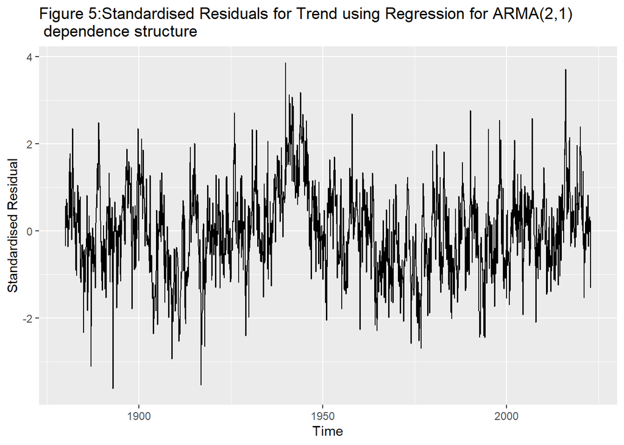

### Predictions

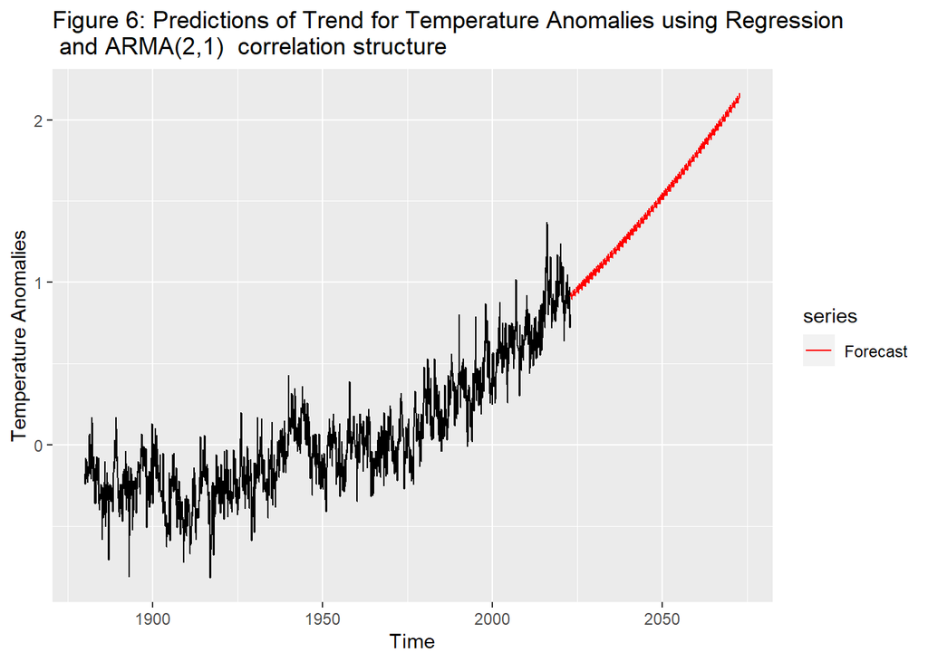

Figure 6 clearly appears to be an improvement over the predictions in Figure 5, as the non-linearity is evident in the later part of the forecast. We observe a clearly increasing trend and also the fact that given the Business as Usual Scenario, we are expected to breach the 1.5 Degree limit before 2050 and the 2 Degree Limit before the end of the century. Lastly, we remark that the Regression approach appears to have captured the variability in the data better than the Sarima approach as it is able to incorporate the non-linearity in the trend.

## Conclusion

We saw in the previous section that there is not enough evidence in the data to support an exponential trend in the temperature anomalies. The trend is adequately modelled by a quadratic term and some effect due to the monthly variations. We also observed that the data is adequately modelled using a linear trend in the period post 1958. This suggests that fossil fuel utilisation, especially the efficient exploitation of natural gas and petroleum, has not been decreased and has been a consistent factor in the temperature increase.

## Appendix

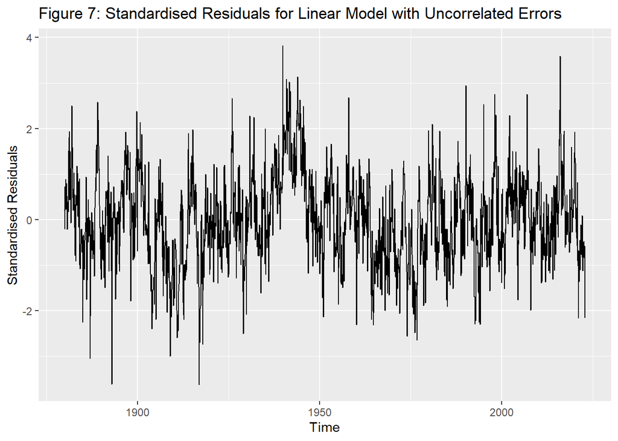

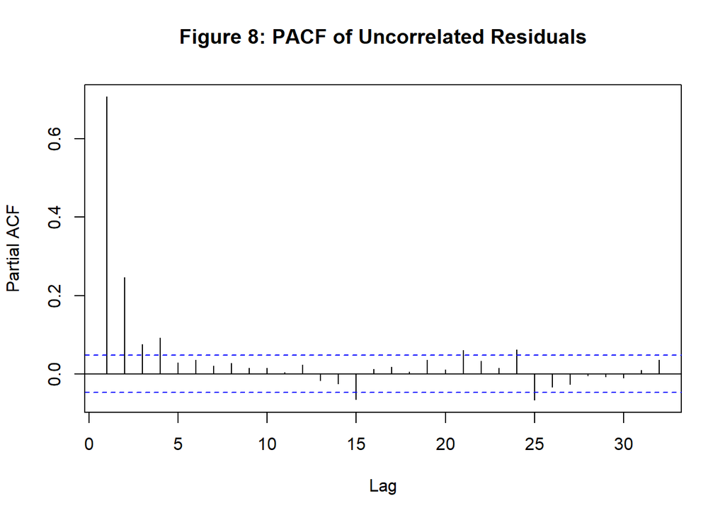

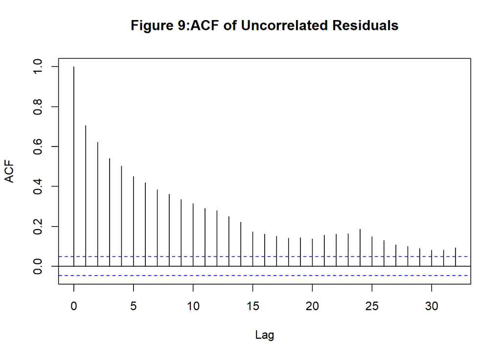